# dsc540_projectml_robert_kaszubski

**Robert Kaszubski**

**DSC540 - Section 810**

**02/27/2022**

**Project ML**

**DATASET: https://archive.ics.uci.edu/ml/datasets/seismic-bumps**

**Problem: Predicting if a seismic hazard will occur while mining**

The Dataset has 2584 observations and 18 variables (excluding the class variable). The variables include energy levels, pulses, seimsic bumps, among a few others. The target variable is refered to as "class" with a 0 representing a nonhazard and 1 representing a hazard.

Methodology:

The goal is to create several classifiers that will best predict whether or not a seismic hazard will occur. To start I'm going to load in the dataset and do some data exploration. This will include looking at the different variables, their distributions, their coorelations, and creating a few different visualization to better represent this.

After this, I will prepare the data for machine learning by converting any categoricaly variables to dummies and splitting the dataset into training and testing. From there I will use several different machine learning models included in the sklearn package, most of these were covered in class and used in previous assignments, but a few I decided to try on my own. These will be evaluated looking at the different metrics. My primary focus is to find models that excel at predicting hazards (1's). There is a large class imbalance with only 6% or so of the dataset being 1's. Therefore it is key to find a model with a high balanced accuracy, f1 score, and recall.

Note: I reran this entire notebook before submitting, so there may be some differences in the results for certain models than what I wrote in the comments

# **Library Imports**

```python
import pandas as pd
import numpy as np
import matplotlib.pyplot as plt
import seaborn as sns

from sklearn import metrics
```

```python
import sklearn
sklearn.__version__
```

```
'1.0.2'
```

Required to read in arff file:

```python
from scipy.io import arff
```

SKlearn model imports:

```python
from sklearn.model_selection import train_test_split
from sklearn.linear_model import LogisticRegression
from sklearn.model_selection import GridSearchCV
from sklearn.model_selection import cross_val_score
from sklearn.model_selection import StratifiedKFold
from sklearn.neighbors import KNeighborsClassifier
from sklearn.naive_bayes import GaussianNB
from sklearn.tree import DecisionTreeClassifier
from sklearn.ensemble import RandomForestClassifier
from sklearn.ensemble import AdaBoostClassifier
from sklearn.ensemble import GradientBoostingClassifier
from sklearn.svm import SVC
from sklearn.linear_model import SGDClassifier
from sklearn.linear_model import Perceptron
from sklearn.neural_network import MLPClassifier
from sklearn.neighbors import NearestCentroid
from sklearn.naive_bayes import BernoulliNB
```

# **Loading Data**

Import data from .arff file:

```python
data = arff.loadarff('seismic-bumps.arff')
df = pd.DataFrame(data[0])
```

```python
df.head()
```

|  | seismic | seismoacoustic | shift | genergy | gpuls | gdenergy | gdpuls | ghazard | nbumps | nbumps2 | nbumps3 | nbumps4 | nbumps5 | nbumps6 | nbumps7 | nbumps89 | energy | maxenergy | class |
| --- | --- | --- | --- | --- | --- | --- | --- | --- | --- | --- | --- | --- | --- | --- | --- | --- | --- | --- | --- |
| 0 | b'a' | b'a' | b'N' | 15180.0 | 48.0 | -72.0 | -72.0 | b'a' | 0.0 | 0.0 | 0.0 | 0.0 | 0.0 | 0.0 | 0.0 | 0.0 | 0.0 | 0.0 | b'0' |
| 1 | b'a' | b'a' | b'N' | 14720.0 | 33.0 | -70.0 | -79.0 | b'a' | 1.0 | 0.0 | 1.0 | 0.0 | 0.0 | 0.0 | 0.0 | 0.0 | 2000.0 | 2000.0 | b'0' |
| 2 | b'a' | b'a' | b'N' | 8050.0 | 30.0 | -81.0 | -78.0 | b'a' | 0.0 | 0.0 | 0.0 | 0.0 | 0.0 | 0.0 | 0.0 | 0.0 | 0.0 | 0.0 | b'0' |
| 3 | b'a' | b'a' | b'N' | 28820.0 | 171.0 | -23.0 | 40.0 | b'a' | 1.0 | 0.0 | 1.0 | 0.0 | 0.0 | 0.0 | 0.0 | 0.0 | 3000.0 | 3000.0 | b'0' |
| 4 | b'a' | b'a' | b'N' | 12640.0 | 57.0 | -63.0 | -52.0 | b'a' | 0.0 | 0.0 | 0.0 | 0.0 | 0.0 | 0.0 | 0.0 | 0.0 | 0.0 | 0.0 | b'0' |

We can see that seismic, seismoacoustic, shift, ghazard, and class haven't been read properly. The b before the value stands for byte. Let's remove it:

```python
df['class'] = df['class'].str.decode('utf-8')
df['class'] = df['class'].astype(str).astype(int)
df['seismic'] = df['seismic'].str.decode('utf-8')
df['seismoacoustic'] = df['seismoacoustic'].str.decode('utf-8')
df['shift'] = df['shift'].str.decode('utf-8')
df['ghazard'] = df['ghazard'].str.decode('utf-8')
```

```python
df.head()
```

|  | seismic | seismoacoustic | shift | genergy | gpuls | gdenergy | gdpuls | ghazard | nbumps | nbumps2 | nbumps3 | nbumps4 | nbumps5 | nbumps6 | nbumps7 | nbumps89 | energy | maxenergy | class |
| --- | --- | --- | --- | --- | --- | --- | --- | --- | --- | --- | --- | --- | --- | --- | --- | --- | --- | --- | --- |
| 0 | a | a | N | 15180.0 | 48.0 | -72.0 | -72.0 | a | 0.0 | 0.0 | 0.0 | 0.0 | 0.0 | 0.0 | 0.0 | 0.0 | 0.0 | 0.0 | 0 |
| 1 | a | a | N | 14720.0 | 33.0 | -70.0 | -79.0 | a | 1.0 | 0.0 | 1.0 | 0.0 | 0.0 | 0.0 | 0.0 | 0.0 | 2000.0 | 2000.0 | 0 |
| 2 | a | a | N | 8050.0 | 30.0 | -81.0 | -78.0 | a | 0.0 | 0.0 | 0.0 | 0.0 | 0.0 | 0.0 | 0.0 | 0.0 | 0.0 | 0.0 | 0 |
| 3 | a | a | N | 28820.0 | 171.0 | -23.0 | 40.0 | a | 1.0 | 0.0 | 1.0 | 0.0 | 0.0 | 0.0 | 0.0 | 0.0 | 3000.0 | 3000.0 | 0 |
| 4 | a | a | N | 12640.0 | 57.0 | -63.0 | -52.0 | a | 0.0 | 0.0 | 0.0 | 0.0 | 0.0 | 0.0 | 0.0 | 0.0 | 0.0 | 0.0 | 0 |

Check for missing data:

```python
df.isnull().sum()
```

```
seismic           0
seismoacoustic    0
shift             0
genergy           0
gpuls             0
gdenergy          0
gdpuls            0
ghazard           0
nbumps            0
nbumps2           0
nbumps3           0
nbumps4           0
nbumps5           0
nbumps6           0
nbumps7           0
nbumps89          0
energy            0
maxenergy         0
class             0
dtype: int64
```

No Missing Data!

# **Exploratory Analysis**

All of the data has now been read in properly.

Lets look at info() and describe()

```python
df.info()
```

```
<class 'pandas.core.frame.DataFrame'>
RangeIndex: 2584 entries, 0 to 2583
Data columns (total 19 columns):
 #   Column          Non-Null Count  Dtype
---  ------          --------------  -----
 0   seismic         2584 non-null   object
 1   seismoacoustic  2584 non-null   object
 2   shift           2584 non-null   object
 3   genergy         2584 non-null   float64
 4   gpuls           2584 non-null   float64
 5   gdenergy        2584 non-null   float64
 6   gdpuls          2584 non-null   float64
 7   ghazard         2584 non-null   object
 8   nbumps          2584 non-null   float64
 9   nbumps2         2584 non-null   float64
 10  nbumps3         2584 non-null   float64
 11  nbumps4         2584 non-null   float64
 12  nbumps5         2584 non-null   float64
 13  nbumps6         2584 non-null   float64
 14  nbumps7         2584 non-null   float64
 15  nbumps89        2584 non-null   float64
 16  energy          2584 non-null   float64
 17  maxenergy       2584 non-null   float64
 18  class           2584 non-null   int64
dtypes: float64(14), int64(1), object(4)
memory usage: 383.7+ KB
```

Again, we have 19 total variables. The target variable will be class. The majority of variables are floats except for the four categorical variables which will have to be turned into dummies.

The target variable class contains either a 0 [nonhazardous] or a 1 [hazardous]

There are 2584 obsevations.

Let's see the class breakdown:

```python
df['class'].value_counts()
```

```
0    2414
1     170
Name: class, dtype: int64
```

We can see that there is a lot more data for nonhazardous seismic events than hazardous. Because of this, it may be harder to train a model to accuractly predict both classes. When splitting the dataset into training and testing, it'll be imporant to have a similar ratio of 0's to 1's in both.

```python
2414/170
```

```
14.2
```

The ratio of 0's to 1's in the data set is about 14 to 1. Meaning that there are 14 nonhazardous events for every 1 hazardous event.

```python
170/2584*100
```

```
6.578947368421052
```

The hazardous state makes up only around 6.58% of the dataset.

```python
df.describe()
```

|  | genergy | gpuls | gdenergy | gdpuls | nbumps | nbumps2 | nbumps3 | nbumps4 | nbumps5 | nbumps6 | nbumps7 | nbumps89 | energy | maxenergy | class |
| --- | --- | --- | --- | --- | --- | --- | --- | --- | --- | --- | --- | --- | --- | --- | --- |
| count | 2.584000e+03 | 2584.000000 | 2584.000000 | 2584.000000 | 2584.000000 | 2584.000000 | 2584.000000 | 2584.000000 | 2584.000000 | 2584.0 | 2584.0 | 2584.0 | 2584.000000 | 2584.000000 | 2584.000000 |
| mean | 9.024252e+04 | 538.579334 | 12.375774 | 4.508901 | 0.859520 | 0.393576 | 0.392802 | 0.067724 | 0.004644 | 0.0 | 0.0 | 0.0 | 4975.270898 | 4278.850619 | 0.065789 |
| std | 2.292005e+05 | 562.652536 | 80.319051 | 63.166556 | 1.364616 | 0.783772 | 0.769710 | 0.279059 | 0.068001 | 0.0 | 0.0 | 0.0 | 20450.833222 | 19357.454882 | 0.247962 |
| min | 1.000000e+02 | 2.000000 | -96.000000 | -96.000000 | 0.000000 | 0.000000 | 0.000000 | 0.000000 | 0.000000 | 0.0 | 0.0 | 0.0 | 0.000000 | 0.000000 | 0.000000 |
| 25% | 1.166000e+04 | 190.000000 | -37.000000 | -36.000000 | 0.000000 | 0.000000 | 0.000000 | 0.000000 | 0.000000 | 0.0 | 0.0 | 0.0 | 0.000000 | 0.000000 | 0.000000 |
| 50% | 2.548500e+04 | 379.000000 | -6.000000 | -6.000000 | 0.000000 | 0.000000 | 0.000000 | 0.000000 | 0.000000 | 0.0 | 0.0 | 0.0 | 0.000000 | 0.000000 | 0.000000 |
| 75% | 5.283250e+04 | 669.000000 | 38.000000 | 30.250000 | 1.000000 | 1.000000 | 1.000000 | 0.000000 | 0.000000 | 0.0 | 0.0 | 0.0 | 2600.000000 | 2000.000000 | 0.000000 |
| max | 2.595650e+06 | 4518.000000 | 1245.000000 | 838.000000 | 9.000000 | 8.000000 | 7.000000 | 3.000000 | 1.000000 | 0.0 | 0.0 | 0.0 | 402000.000000 | 400000.000000 | 1.000000 |

The describe method gives a statistical summary of the numerical variables.

Again, I believe those data points belonging to the upper end of the distributions of these variables, is likely corresponding to hazardous seismic states/events.

We can also remove nbumps6, nbumps7, and nbumps89. We can see that the value remains at 0 for the entirety of the dataset. That means there were 0 seismic bumps in the energy range those variables correspond to thus they are not needed.

```python
df = df.drop(columns=['nbumps6','nbumps7','nbumps89'])
df.head(5)
```

|  | seismic | seismoacoustic | shift | genergy | gpuls | gdenergy | gdpuls | ghazard | nbumps | nbumps2 | nbumps3 | nbumps4 | nbumps5 | energy | maxenergy | class |
| --- | --- | --- | --- | --- | --- | --- | --- | --- | --- | --- | --- | --- | --- | --- | --- | --- |
| 0 | a | a | N | 15180.0 | 48.0 | -72.0 | -72.0 | a | 0.0 | 0.0 | 0.0 | 0.0 | 0.0 | 0.0 | 0.0 | 0 |
| 1 | a | a | N | 14720.0 | 33.0 | -70.0 | -79.0 | a | 1.0 | 0.0 | 1.0 | 0.0 | 0.0 | 2000.0 | 2000.0 | 0 |
| 2 | a | a | N | 8050.0 | 30.0 | -81.0 | -78.0 | a | 0.0 | 0.0 | 0.0 | 0.0 | 0.0 | 0.0 | 0.0 | 0 |
| 3 | a | a | N | 28820.0 | 171.0 | -23.0 | 40.0 | a | 1.0 | 0.0 | 1.0 | 0.0 | 0.0 | 3000.0 | 3000.0 | 0 |
| 4 | a | a | N | 12640.0 | 57.0 | -63.0 | -52.0 | a | 0.0 | 0.0 | 0.0 | 0.0 | 0.0 | 0.0 | 0.0 | 0 |

Let's look at correlations between the variables

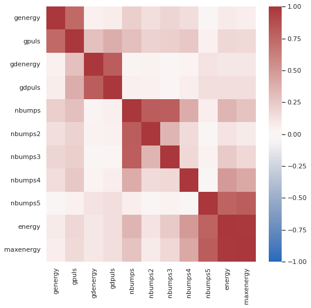

```python
corrdf = df.drop(columns=['class']).corr()
sns.set(rc = {'figure.figsize':(8,8)})
sns.heatmap(corrdf, vmin=-1, vmax=1, cmap='vlag')
```

```python
corrdf
```

|  | genergy | gpuls | gdenergy | gdpuls | nbumps | nbumps2 | nbumps3 | nbumps4 | nbumps5 | energy | maxenergy |
| --- | --- | --- | --- | --- | --- | --- | --- | --- | --- | --- | --- |
| genergy | 1.000000 | 0.748020 | 0.048514 | 0.071554 | 0.220720 | 0.143587 | 0.191753 | 0.150589 | -0.009863 | 0.080828 | 0.064405 |
| gpuls | 0.748020 | 1.000000 | 0.293036 | 0.382906 | 0.300923 | 0.207390 | 0.225695 | 0.256547 | 0.049450 | 0.187350 | 0.164263 |
| gdenergy | 0.048514 | 0.293036 | 1.000000 | 0.811944 | 0.030039 | 0.041246 | -0.012189 | 0.036916 | 0.123229 | 0.105971 | 0.108572 |
| gdpuls | 0.071554 | 0.382906 | 0.811944 | 1.000000 | 0.057996 | 0.051106 | 0.014735 | 0.066195 | 0.141044 | 0.143277 | 0.143646 |
| nbumps | 0.220720 | 0.300923 | 0.030039 | 0.057996 | 1.000000 | 0.804978 | 0.803364 | 0.395052 | 0.069613 | 0.347852 | 0.273714 |
| nbumps2 | 0.143587 | 0.207390 | 0.041246 | 0.051106 | 0.804978 | 1.000000 | 0.350724 | 0.161296 | -0.005251 | 0.124650 | 0.085032 |
| nbumps3 | 0.191753 | 0.225695 | -0.012189 | 0.014735 | 0.803364 | 0.350724 | 1.000000 | 0.175301 | 0.046498 | 0.244083 | 0.176480 |
| nbumps4 | 0.150589 | 0.256547 | 0.036916 | 0.066195 | 0.395052 | 0.161296 | 0.175301 | 1.000000 | -0.016580 | 0.489828 | 0.416483 |
| nbumps5 | -0.009863 | 0.049450 | 0.123229 | 0.141044 | 0.069613 | -0.005251 | 0.046498 | -0.016580 | 1.000000 | 0.773605 | 0.808406 |
| energy | 0.080828 | 0.187350 | 0.105971 | 0.143277 | 0.347852 | 0.124650 | 0.244083 | 0.489828 | 0.773605 | 1.000000 | 0.989547 |
| maxenergy | 0.064405 | 0.164263 | 0.108572 | 0.143646 | 0.273714 | 0.085032 | 0.176480 | 0.416483 | 0.808406 | 0.989547 | 1.000000 |

There aren't very many variables that are moderatly or strongly correlated.

The highest correlation is between energy and max energy. The correlation is very strong in this case at .99.

Finally, we can see some correlation between nbumps and nbumps2/nbumps3. nbumps refers to just the total number of seismic bumps while the numbered variables break it down further by energy range. So summing all of the numbered nbumps(1,2,3,4,5) should equal the value in nbumps

Let's create some visualizations

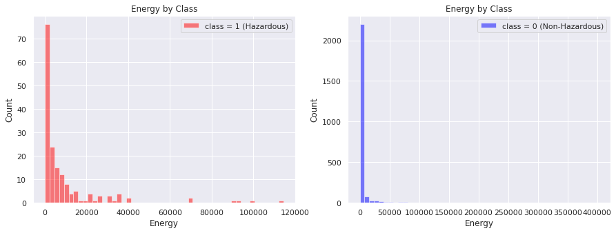

```python
plt.figure(figsize=(15,5))
plt.subplot(1, 2, 1)
df[df['class']==1]['energy'].hist(bins=50,color='red',label='class = 1 (Hazardous)',alpha=.5 )
plt.legend()
plt.xlabel("Energy")
plt.ylabel("Count")
plt.title("Energy by Class")
plt.subplot(1, 2, 2)
df[df['class']==0]['energy'].hist(bins=50,color='blue',label='class = 0 (Non-Hazardous)',alpha=.5 )
plt.legend()
plt.xlabel("Energy")
plt.ylabel("Count")
plt.title("Energy by Class")
```

We can see that in either scenario the majority of data falls into the low energy range.

However, it is suprising to see that the max energy point falls under the non-hazardous class. This will likely make classification a little complicated as it isn't as simple as I imagined it to be before in which higher energy corresponded to hazardous events.

Let me recreate the second plot for non-hazardous events excluding the low energy points, so we can see the higher energy a bit better. The y axis scales are very different in the current plot due to the fact that there is so much more data for class = 0.

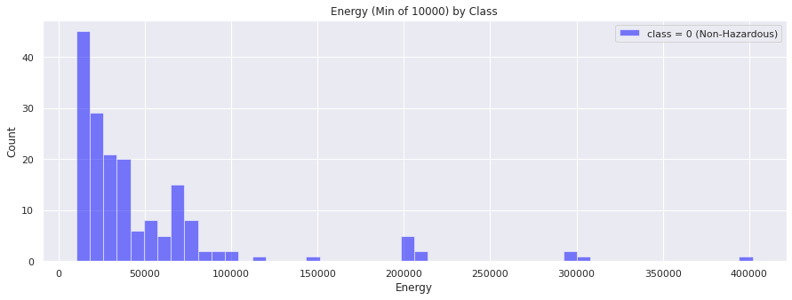

```python
plt.figure(figsize=(15,5))
df.loc[(df['class']==0) & (df['energy']>10000)]['energy'].hist(bins=50,color='blue',label='class = 0 (Non-Hazardous)',alpha=.5 )
plt.legend()
plt.xlabel("Energy")
plt.ylabel("Count")
plt.title("Energy (Min of 10000) by Class")
```

This allows us to better see the handful of points that have very high energy yet are classified as non hazardous.

```
[Text(0.5, 1.0, 'gpuls vs gdenergy')]
```

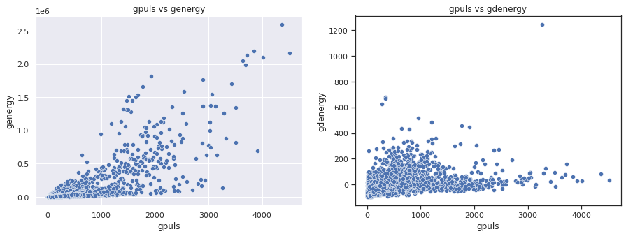

```python
plt.figure(figsize=(15,5))
plt.subplot(1, 2, 1)
sns.set_style('ticks')
sns.scatterplot(data=df, x="gpuls", y="genergy").set(title="gpuls vs genergy")
plt.subplot(1, 2, 2)
sns.set_style('ticks')
sns.scatterplot(data=df, x="gpuls", y="gdenergy").set(title="gpuls vs gdenergy")
```

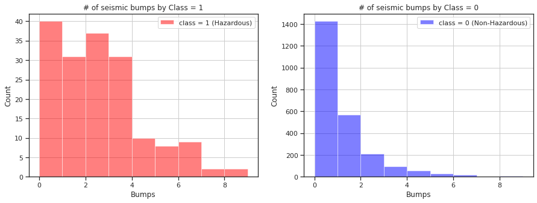

```python
plt.figure(figsize=(15,5))
plt.title("# of seismic bumps by Class")
plt.subplot(1, 2, 1)
df[df['class']==1]['nbumps'].hist(bins=9,color='red',label='class = 1 (Hazardous)',alpha=.5 )
plt.legend()
plt.xlabel("Bumps")
plt.ylabel("Count")
plt.title("# of seismic bumps by Class = 1")
plt.subplot(1, 2, 2)
df[df['class']==0]['nbumps'].hist(bins=9,color='blue',label='class = 0 (Non-Hazardous)',alpha=.5 )
plt.legend()
plt.xlabel("Bumps")
plt.ylabel("Count")
plt.title("# of seismic bumps by Class = 0")
```

This gives us a good look at the difference in distribution by class for nbumps. While we have a lot more data for non-hazardous class 0, we can see that the majority of events have 0 bumps. Unlike with class 1, theres a pretty even distribution between 0,1,2,3 bumps.

This will likely be a good variable in predicting whether an event is hazardous or non hazardous

I wanted to look at the relationship between nbumps and energy. It seems so far that more seismic bumps means a greater likelihood of a hazardous state. However, as seen in the energy plots, there have been situations with very high energy yet were classified as non-hazardous.

```
[Text(0.5, 1.0, 'nbumps vs genergy')]
```

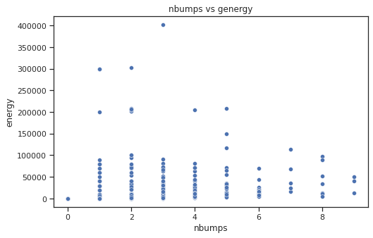

```python
plt.figure(figsize=(8,5))
sns.set_style('ticks')
sns.scatterplot(data=df, x="nbumps", y="energy").set(title="nbumps vs genergy")
```

As expected based on the correlation plot, theres no discernable relationship here.

Finally I want to look at the ratio of the different nbump variables. nbumps represents the total, so nbumps2,3,4,5 should add up to it. nbumps5 is the highest energy range featured in the dataset.

```python
df[['nbumps','nbumps2','nbumps3','nbumps4','nbumps5']].sum()
```

```
nbumps     2221.0
nbumps2    1017.0
nbumps3    1015.0
nbumps4     175.0
nbumps5      12.0
dtype: float64
```

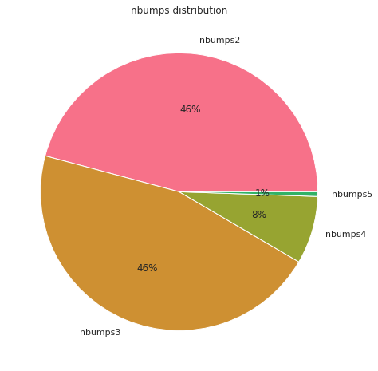

```python
nbumps2_sum = df['nbumps2'].sum()
nbumps3_sum = df['nbumps3'].sum()
nbumps4_sum = df['nbumps4'].sum()
nbumps5_sum = df['nbumps5'].sum()
colors = sns.color_palette("husl", 8)
plt.pie([nbumps2_sum,nbumps3_sum,nbumps4_sum,nbumps5_sum], labels = ['nbumps2', 'nbumps3', 'nbumps4', 'nbumps5'], colors = colors, autopct='%.0f%%')
plt.title('nbumps distribution')
```

We can see an equal percentage of seismic bumps falls into the 2 and 3 range ([10^2,10^3) , [10^3,10^4) )

About 8% falls into the 4 range ([10^4,10^5))

And only 12 isntances or about 1% fall into the 5 range [10^5,10^6)

# **Final Preparations for Machine Learning**

```python
df.info()
```

```
<class 'pandas.core.frame.DataFrame'>
RangeIndex: 2584 entries, 0 to 2583
Data columns (total 16 columns):
 #   Column          Non-Null Count  Dtype
---  ------          --------------  -----
 0   seismic         2584 non-null   object
 1   seismoacoustic  2584 non-null   object
 2   shift           2584 non-null   object
 3   genergy         2584 non-null   float64
 4   gpuls           2584 non-null   float64
 5   gdenergy        2584 non-null   float64
 6   gdpuls          2584 non-null   float64
 7   ghazard         2584 non-null   object
 8   nbumps          2584 non-null   float64
 9   nbumps2         2584 non-null   float64
 10  nbumps3         2584 non-null   float64
 11  nbumps4         2584 non-null   float64
 12  nbumps5         2584 non-null   float64
 13  energy          2584 non-null   float64
 14  maxenergy       2584 non-null   float64
 15  class           2584 non-null   int64
dtypes: float64(11), int64(1), object(4)
memory usage: 323.1+ KB
```

There are 4 categorical variables that will have to be converted to dummy variables.

```python
dummy = ['seismic','seismoacoustic','shift','ghazard']
df_final = loans = pd.get_dummies(df,columns=dummy)
```

```python
df_final.head()
```

|  | genergy | gpuls | gdenergy | gdpuls | nbumps | nbumps2 | nbumps3 | nbumps4 | nbumps5 | energy | maxenergy | class | seismic_a | seismic_b | seismoacoustic_a | seismoacoustic_b | seismoacoustic_c | shift_N | shift_W | ghazard_a | ghazard_b | ghazard_c |
| --- | --- | --- | --- | --- | --- | --- | --- | --- | --- | --- | --- | --- | --- | --- | --- | --- | --- | --- | --- | --- | --- | --- |
| 0 | 15180.0 | 48.0 | -72.0 | -72.0 | 0.0 | 0.0 | 0.0 | 0.0 | 0.0 | 0.0 | 0.0 | 0 | 1 | 0 | 1 | 0 | 0 | 1 | 0 | 1 | 0 | 0 |
| 1 | 14720.0 | 33.0 | -70.0 | -79.0 | 1.0 | 0.0 | 1.0 | 0.0 | 0.0 | 2000.0 | 2000.0 | 0 | 1 | 0 | 1 | 0 | 0 | 1 | 0 | 1 | 0 | 0 |
| 2 | 8050.0 | 30.0 | -81.0 | -78.0 | 0.0 | 0.0 | 0.0 | 0.0 | 0.0 | 0.0 | 0.0 | 0 | 1 | 0 | 1 | 0 | 0 | 1 | 0 | 1 | 0 | 0 |
| 3 | 28820.0 | 171.0 | -23.0 | 40.0 | 1.0 | 0.0 | 1.0 | 0.0 | 0.0 | 3000.0 | 3000.0 | 0 | 1 | 0 | 1 | 0 | 0 | 1 | 0 | 1 | 0 | 0 |
| 4 | 12640.0 | 57.0 | -63.0 | -52.0 | 0.0 | 0.0 | 0.0 | 0.0 | 0.0 | 0.0 | 0.0 | 0 | 1 | 0 | 1 | 0 | 0 | 1 | 0 | 1 | 0 | 0 |

Now all that has to be done is splitting the data into training and testing.

```python
X = df_final.drop('class',axis=1)
y = df_final['class']
X_train, X_test, y_train, y_test = train_test_split(X, y, test_size=0.30, stratify=y, random_state=2020)
```

Last thing I want to verify is that the ratio of class 1 to 0, is close between the train and test set.

I used stratify to ensure it is split evenly.

```python
y_train.value_counts()
```

```
0    1689
1     119
Name: class, dtype: int64
```

```python
1689/119
```

```
14.193277310924369
```

```python
y_test.value_counts()
```

```
0    725
1     51
Name: class, dtype: int64
```

```python
725/51
```

```
14.215686274509803
```

Since I'm going to be using grid search CV for tuning:

```python
cv = StratifiedKFold(n_splits=5, shuffle=True, random_state=0)
```

Now I can start testing several different models:

# **Logistic Regression**

I wanted to start with Logistic Regression without any changed parameters:

```python
clf = LogisticRegression()
```

```python
clf.fit(X_train, y_train)
```

```
LogisticRegression()
```

```python
pred = clf.predict(X_train)
metrics.accuracy_score(y_true = y_train, y_pred = pred)
```

```
0.9021017699115044
```

```python
pred = clf.predict(X_test)
metrics.accuracy_score(y_true = y_test, y_pred = pred)
```

```
0.9110824742268041
```

```python
confusion_matrix =  pd.crosstab(index = y_test, columns=pred.ravel(), rownames=['Expected'], colnames=['Predicted'])
confusion_matrix
```

| Predicted Expected | 0 | 1 |
| --- | --- | --- |
| 0 | 705 | 20 |
| 1 | 49 | 2 |

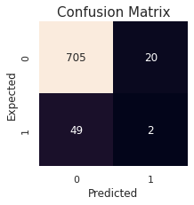

```python
sns.set(rc = {'figure.figsize':(3,3)})
sns.heatmap(confusion_matrix, annot=True, cbar=False, fmt='g')
plt.title("Confusion Matrix", fontsize = 15)
plt.show()
```

```python
print (metrics.classification_report(y_test, pred))
```

```
              precision    recall  f1-score   support

           0       0.94      0.97      0.95       725
           1       0.09      0.04      0.05        51

    accuracy                           0.91       776
   macro avg       0.51      0.51      0.50       776
weighted avg       0.88      0.91      0.89       776
```

The accuracy is quite good at 91% however the important thing to pay attention to is that it isn't predicting 1's at all. The recall and precision values are key here. We are trying to predict when hazardous activity DOES happen. This isn't doing that.

Lets run grid search:

The different solvers for logistic regression are quite picky, so I can only test a l2 and none penalty at the same time

```python
params = dict(
    max_iter = [100,1000],
    solver=['lbfgs','newton-cg','sag','saga'],
    penalty=['l2','none'],
    C=[0.01,0.1,1,2]
)
```

```python
lr = LogisticRegression()
gs = GridSearchCV(estimator=lr, param_grid=params, scoring='f1', cv=cv, n_jobs=-1)
gs.fit(X_train, y_train)
gs.best_params_
```

```
{'C': 1, 'max_iter': 100, 'penalty': 'l2', 'solver': 'lbfgs'}
```

```python
best_estimator = gs.best_estimator_

pred = best_estimator.predict(X_test)
metrics.accuracy_score(y_test, pred)
```

```
0.9110824742268041
```

```python
confusion_matrix =  pd.crosstab(index = y_test, columns=pred.ravel(), rownames=['Expected'], colnames=['Predicted'])
confusion_matrix
```

| Predicted Expected | 0 | 1 |
| --- | --- | --- |
| 0 | 705 | 20 |
| 1 | 49 | 2 |

```python
print(metrics.classification_report(y_test, pred))
```

```
              precision    recall  f1-score   support

           0       0.94      0.97      0.95       725
           1       0.09      0.04      0.05        51

    accuracy                           0.91       776
   macro avg       0.51      0.51      0.50       776
weighted avg       0.88      0.91      0.89       776
```

There isn't much that can be done with this model. Trying different parameters still ends up with the default parameters working best. There's no improvement to recall or f1.

Balanced accuracy is only .505 and the f1 is poor at .05

# **KNN Classifier**

Let's try a KNN classifier. As a baseline I'll try K = 3.

```python
nn = KNeighborsClassifier(n_neighbors=3)
nn.fit(X_train, y_train)
pred = nn.predict(X_train)
metrics.accuracy_score(y_true = y_train, y_pred = pred)
```

```
0.9435840707964602
```

```python
pred = nn.predict(X_test)
metrics.accuracy_score(y_true = y_test, y_pred = pred)
```

```
0.9162371134020618
```

```python
confusion_matrix =  pd.crosstab(index = y_test, columns=pred.ravel(), rownames=['Expected'], colnames=['Predicted'])
confusion_matrix
```

| Predicted Expected | 0 | 1 |
| --- | --- | --- |
| 0 | 709 | 16 |
| 1 | 49 | 2 |

```python
print (metrics.classification_report(y_test, pred))
```

```
              precision    recall  f1-score   support

           0       0.94      0.98      0.96       725
           1       0.11      0.04      0.06        51

    accuracy                           0.92       776
   macro avg       0.52      0.51      0.51       776
weighted avg       0.88      0.92      0.90       776
```

This is still not predicting 1's very frequently.

Let me try adjusting the parameters

```python
params = dict(
    n_neighbors = [1,2,3,5,7,9,10,15,20],
    weights = ['distance'],
    p = [1,2]
)

nn = KNeighborsClassifier()
gs = GridSearchCV(estimator=nn, param_grid=params, scoring='f1', cv=cv, n_jobs=-1)
gs.fit(X_train, y_train)
gs.best_params_
```

```
{'n_neighbors': 1, 'p': 1, 'weights': 'distance'}
```

```python
best_estimator = gs.best_estimator_

pred = best_estimator.predict(X_test)
metrics.accuracy_score(y_test, pred)
```

```
0.884020618556701
```

```python
confusion_matrix =  pd.crosstab(index = y_test, columns=pred.ravel(), rownames=['Expected'], colnames=['Predicted'])
confusion_matrix
```

| Predicted Expected | 0 | 1 |
| --- | --- | --- |
| 0 | 681 | 44 |
| 1 | 46 | 5 |

```python
print(metrics.classification_report(y_test, pred))
```

```
              precision    recall  f1-score   support

           0       0.94      0.94      0.94       725
           1       0.10      0.10      0.10        51

    accuracy                           0.88       776
   macro avg       0.52      0.52      0.52       776
weighted avg       0.88      0.88      0.88       776
```

Very tiny improvement here. It's correctly predicting 5 1's or about 10% of the test set. The F1 score has improved as has the recall and precision. But this still isn't a good model.

Last thing I want to try here is a different algorithm. I'll keep manhattan distance (p = 1). I also added in more values for K.

```python
params = dict(
    n_neighbors = [1,2,3,5,7,9,10,15,20,50,99],
    weights = ['distance'],
    p = [1],
    algorithm = ['ball_tree','kd_tree','brute']
)

nn = KNeighborsClassifier()
gs = GridSearchCV(estimator=nn, param_grid=params, scoring='f1', cv=cv, n_jobs=-1)
gs.fit(X_train, y_train)
gs.best_params_
```

```
{'algorithm': 'ball_tree', 'n_neighbors': 1, 'p': 1, 'weights': 'distance'}
```

```python
best_estimator = gs.best_estimator_

pred = best_estimator.predict(X_test)
metrics.accuracy_score(y_test, pred)
```

```
0.884020618556701
```

```python
confusion_matrix =  pd.crosstab(index = y_test, columns=pred.ravel(), rownames=['Expected'], colnames=['Predicted'])
confusion_matrix
```

| Predicted Expected | 0 | 1 |
| --- | --- | --- |
| 0 | 681 | 44 |
| 1 | 46 | 5 |

```python
print(metrics.classification_report(y_test, pred))
```

```
              precision    recall  f1-score   support

           0       0.94      0.94      0.94       725
           1       0.10      0.10      0.10        51

    accuracy                           0.88       776
   macro avg       0.52      0.52      0.52       776
weighted avg       0.88      0.88      0.88       776
```

No further improvement was made.

Balanced accuracy is .52

# **Gaussian Naive Bayes**

Let me try the gaussian naive bayes model:

```python
gnb = GaussianNB()
gnb.fit(X_train, y_train)
pred = gnb.predict(X_train)
metrics.accuracy_score(y_true = y_train, y_pred = pred)
```

```
0.9043141592920354
```

```python
pred = gnb.predict(X_test)
metrics.accuracy_score(y_true = y_test, y_pred = pred)
```

```
0.8969072164948454
```

```python
confusion_matrix =  pd.crosstab(index = y_test, columns=pred.ravel(), rownames=['Expected'], colnames=['Predicted'])
confusion_matrix
```

| Predicted Expected | 0 | 1 |
| --- | --- | --- |
| 0 | 686 | 39 |
| 1 | 41 | 10 |

```python
print (metrics.classification_report(y_test, pred))
```

```
              precision    recall  f1-score   support

           0       0.94      0.95      0.94       725
           1       0.20      0.20      0.20        51

    accuracy                           0.90       776
   macro avg       0.57      0.57      0.57       776
weighted avg       0.90      0.90      0.90       776
```

Already without any tuning this is the best model. THe recall is the highest its been at 20, as is the f1 and precision. Specificity is also still high at .95. So this model is able to predict 1's much better than the others while still being able to predict 0 very well.

The balanced accuracy is .575

Let me try tuning the model a little bit. The only thing that can be changed is the var_smoothing.

```python
gnb = GaussianNB(var_smoothing = 0.000000000001)
gnb.fit(X_train, y_train)
pred = gnb.predict(X_test)
metrics.accuracy_score(y_true = y_test, y_pred = pred)
```

```
0.8646907216494846
```

```python
confusion_matrix =  pd.crosstab(index = y_test, columns=pred.ravel(), rownames=['Expected'], colnames=['Predicted'])
confusion_matrix
```

| Predicted Expected | 0 | 1 |
| --- | --- | --- |
| 0 | 646 | 79 |
| 1 | 26 | 25 |

```python
print (metrics.classification_report(y_test, pred))
```

```
              precision    recall  f1-score   support

           0       0.96      0.89      0.92       725
           1       0.24      0.49      0.32        51

    accuracy                           0.86       776
   macro avg       0.60      0.69      0.62       776
weighted avg       0.91      0.86      0.89       776
```

By using a var_smoothing value much lower than the default, the results have improved tremendously. We can see a much higher recall of .49 meaning that the model is predicting many more 1's. The specificity is still relatively high albeit slightly smaller than before at .89. So for the most part it's still predicting 0's well just not as well as before. The f1 score is the highest it's been at .32.

I tried a few different var_smoothing values. This gave the most balanced results. Adding or subtracting 0's from the var_smoothing value would end up decreasing the f1-score and balanced accuracy.

The balanced accuracy now is .69, which is a big improvement over the original naive bayes model!

# **Decision Tree**

Next I want to try decision trees. I expect that decision trees and random forest models should work pretty well on this data:

```python
dt = DecisionTreeClassifier()
dt.fit(X_train,y_train)

pred = dt.predict(X_train)
metrics.accuracy_score(y_true = y_train, y_pred = pred)
```

```
1.0
```

```python
pred = dt.predict(X_test)
metrics.accuracy_score(y_true = y_test, y_pred = pred)
```

```
0.8827319587628866
```

```python
confusion_matrix =  pd.crosstab(index = y_test, columns=pred.ravel(), rownames=['Expected'], colnames=['Predicted'])
confusion_matrix
```

| Predicted Expected | 0 | 1 |
| --- | --- | --- |
| 0 | 677 | 48 |
| 1 | 43 | 8 |

```python
print (metrics.classification_report(y_test, pred))
```

```
              precision    recall  f1-score   support

           0       0.94      0.93      0.94       725
           1       0.14      0.16      0.15        51

    accuracy                           0.88       776
   macro avg       0.54      0.55      0.54       776
weighted avg       0.89      0.88      0.89       776
```

Tweaking max_depth. Maybe a less complicated tree will see some improvement:

```python
max_depth = [None,1,2,3,4,5,6,7,8,9,10]

scores_params = []
for m in max_depth:
    dt = DecisionTreeClassifier(max_depth=m)
    scores = cross_val_score(dt, X=X_train, y=y_train, scoring='f1', cv=cv)
    scores_params.append(scores.mean())
```

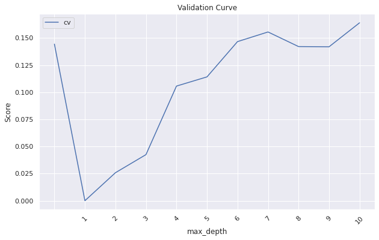

```python
plt.figure(figsize=(10,6))
plt.plot(scores_params, label = 'cv')
plt.xticks(np.arange(len(max_depth)), max_depth, rotation=45)
plt.xlabel('max_depth')
plt.ylabel('Score')
plt.title('Validation Curve')
plt.legend()
plt.show()
```

```python
dt = DecisionTreeClassifier(max_depth=None)
dt.fit(X_train,y_train)
pred = dt.predict(X_test)
print (metrics.classification_report(y_test, pred))
```

```
              precision    recall  f1-score   support

           0       0.94      0.94      0.94       725
           1       0.14      0.14      0.14        51

    accuracy                           0.89       776
   macro avg       0.54      0.54      0.54       776
weighted avg       0.89      0.89      0.89       776
```

Let me try tuning min_samples_split

```python
min_samples_split = [2,3,4,5,6,7,8,9,10, 20, 25, 30, 40, 50,100, 200, 300, 400, 500, 600, 700, 800, 900, 1000]

scores_params = []
for m in min_samples_split:
    dt = DecisionTreeClassifier(min_samples_split=m)
    scores = cross_val_score(dt, X=X_train, y=y_train, scoring='f1', cv=cv)
    scores_params.append(scores.mean())
```

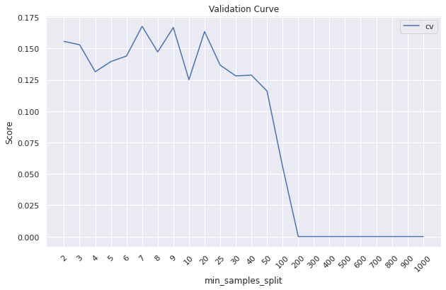

```python
plt.figure(figsize=(10,6))
plt.plot(scores_params, label = 'cv')
plt.xticks(np.arange(len(min_samples_split)), min_samples_split, rotation=45)
plt.xlabel('min_samples_split')
plt.ylabel('Score')
plt.title('Validation Curve')
plt.legend()
plt.show()
```

```python
dt = DecisionTreeClassifier(max_depth=None, min_samples_split=10)
dt.fit(X_train,y_train)
pred = dt.predict(X_test)
print (metrics.classification_report(y_test, pred))
```

```
              precision    recall  f1-score   support

           0       0.94      0.97      0.95       725
           1       0.17      0.10      0.12        51

    accuracy                           0.91       776
   macro avg       0.55      0.53      0.54       776
weighted avg       0.89      0.91      0.90       776
```

This ended up dropping the recall and f1 of the model.

Let me try grid search:

```python
params = dict(
    min_samples_split = [2,3,4,5,6,7,8,9,10, 20, 25, 30, 40, 50,100, 200, 300, 400, 500, 600, 700, 800, 900, 1000],
    max_depth = [None,1,2,3,4,5,6,7,8,9,10]
)
dt = DecisionTreeClassifier()
gs = GridSearchCV(estimator=dt, param_grid=params, scoring='f1', cv=cv, n_jobs=-1)
gs.fit(X_train, y_train)
gs.best_params_
```

```
{'max_depth': 10, 'min_samples_split': 4}
```

```python
best_estimator = gs.best_estimator_

pred = best_estimator.predict(X_test)
metrics.accuracy_score(y_test, pred)
```

```
0.904639175257732
```

```python
confusion_matrix =  pd.crosstab(index = y_test, columns=pred.ravel(), rownames=['Expected'], colnames=['Predicted'])
confusion_matrix
```

| Predicted Expected | 0 | 1 |
| --- | --- | --- |
| 0 | 696 | 29 |
| 1 | 45 | 6 |

```python
print(metrics.classification_report(y_test, pred))
```

```
              precision    recall  f1-score   support

           0       0.94      0.96      0.95       725
           1       0.17      0.12      0.14        51

    accuracy                           0.90       776
   macro avg       0.56      0.54      0.54       776
weighted avg       0.89      0.90      0.90       776
```

Oddly enough the model returned by gridsearch isn't very good at all. The baseline model and model specifiying max_depth = None returned better results...

```python
dt = DecisionTreeClassifier(max_depth=None)
dt.fit(X_train,y_train)
pred = dt.predict(X_test)
print (metrics.classification_report(y_test, pred))
```

```
              precision    recall  f1-score   support

           0       0.94      0.93      0.93       725
           1       0.12      0.14      0.13        51

    accuracy                           0.88       776
   macro avg       0.53      0.53      0.53       776
weighted avg       0.89      0.88      0.88       776
```

```python
metrics.accuracy_score(y_true = y_test, y_pred = pred)
```

```
0.8788659793814433
```

```python
confusion_matrix =  pd.crosstab(index = y_test, columns=pred.ravel(), rownames=['Expected'], colnames=['Predicted'])
confusion_matrix
```

| Predicted Expected | 0 | 1 |
| --- | --- | --- |
| 0 | 675 | 50 |
| 1 | 44 | 7 |

This is the best decision tree model. But it's not anywhere close to as good as the gaussian naive bayes model.

# **Random Forest**

I expect that random forest will work a little bit better than the decision tree which was underwhelming. As it creates a whole forest of trees, the prediction should be better than a single individual tree...

```python
rf = RandomForestClassifier()
rf.fit(X_train,y_train)
pred = rf.predict(X_train)
metrics.accuracy_score(y_true = y_train, y_pred = pred)
```

```
1.0
```

```python
pred = rf.predict(X_test)
metrics.accuracy_score(y_true = y_test, y_pred = pred)
```

```
0.9368556701030928
```

The testing accuracy of the base model is already higher than the models tested earlier.

```python
confusion_matrix =  pd.crosstab(index = y_test, columns=pred.ravel(), rownames=['Expected'], colnames=['Predicted'])
confusion_matrix
```

| Predicted Expected | 0 | 1 |
| --- | --- | --- |
| 0 | 724 | 1 |
| 1 | 48 | 3 |

But unfortunetly, it's accuracy is only high because it predicts 0's (non hazardous) very well and not the 1's which is what we should be focusing on. So the accuracy may be high but the balanced accuracy is likely low. Let's check

```python
print (metrics.classification_report(y_test, pred))
```

```
              precision    recall  f1-score   support

           0       0.94      1.00      0.97       725
           1       0.75      0.06      0.11        51

    accuracy                           0.94       776
   macro avg       0.84      0.53      0.54       776
weighted avg       0.93      0.94      0.91       776
```

Let me try tuning some of the individual parameters:

```python
min_samples_split = [2,3,4,5,6,7,8,9, 10, 20, 25, 30, 40, 50,100, 200, 300, 400, 500, 600, 700, 800, 900, 1000]

scores_params = []
for m in min_samples_split:
    rf = RandomForestClassifier(min_samples_split=m)
    scores = cross_val_score(rf, X=X_train, y=y_train, scoring='f1', cv=cv)
    scores_params.append(scores.mean())
```

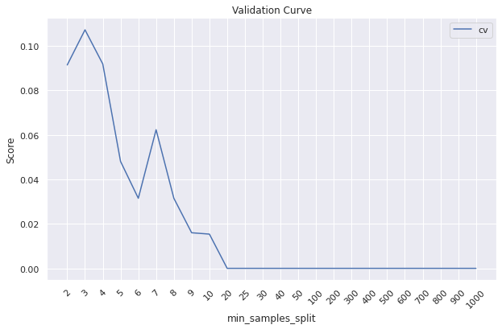

```python
plt.figure(figsize=(10,6))
plt.plot(scores_params, label = 'cv')
plt.xticks(np.arange(len(min_samples_split)), min_samples_split, rotation=45)
plt.xlabel('min_samples_split')
plt.ylabel('Score')
plt.title('Validation Curve')
plt.legend()
plt.show()
```

```python
rf = RandomForestClassifier(min_samples_split=6)
rf.fit(X_train,y_train)
pred = rf.predict(X_test)
metrics.accuracy_score(y_true = y_test, y_pred = pred)
```

```
0.9317010309278351
```

Accuracy is still high lets look at the other metrics.

```python
print (metrics.classification_report(y_test, pred))
```

```
              precision    recall  f1-score   support

           0       0.94      1.00      0.96       725
           1       0.25      0.02      0.04        51

    accuracy                           0.93       776
   macro avg       0.59      0.51      0.50       776
weighted avg       0.89      0.93      0.90       776
```

The model got even worse. It's likely predicting everything as a 0.

```python
confusion_matrix =  pd.crosstab(index = y_test, columns=pred.ravel(), rownames=['Expected'], colnames=['Predicted'])
confusion_matrix
```

| Predicted Expected | 0 | 1 |
| --- | --- | --- |
| 0 | 722 | 3 |
| 1 | 50 | 1 |

Let me try tuning max depth again:

```python
max_depth = [None,1,2,3,4,5,6,7,8,9,10]

scores_params = []
for m in max_depth:
    rf = RandomForestClassifier(max_depth=m)
    scores = cross_val_score(rf, X=X_train, y=y_train, scoring='f1', cv=cv)
    scores_params.append(scores.mean())
```

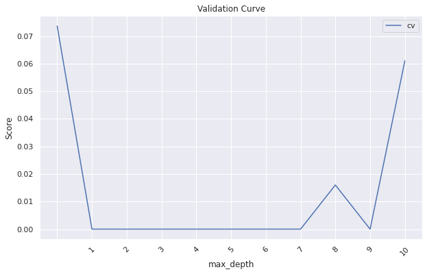

```python
plt.figure(figsize=(10,6))
plt.plot(scores_params, label = 'cv')
plt.xticks(np.arange(len(max_depth)), max_depth, rotation=45)
plt.xlabel('max_depth')
plt.ylabel('Score')
plt.title('Validation Curve')
plt.legend()
plt.show()
```

None is winning again just as in the basic decision tree model. We can see however, that using too small of a max_depth, results in a f1 score of 0 meaning that the model is likely not predicting any 1's correctly. It seems that using this data we want a more complicated model to capture the nuances of a hazardous seismic event.

```python
rf = RandomForestClassifier(max_depth=None)
rf.fit(X_train,y_train)
pred = rf.predict(X_test)
metrics.accuracy_score(y_true = y_test, y_pred = pred)
```

```
0.9317010309278351
```

```python
print (metrics.classification_report(y_test, pred))
```

```
              precision    recall  f1-score   support

           0       0.94      1.00      0.96       725
           1       0.25      0.02      0.04        51

    accuracy                           0.93       776
   macro avg       0.59      0.51      0.50       776
weighted avg       0.89      0.93      0.90       776
```

Let me adjust n_estimators. I don't expect this too make too much of a difference. Essentially it's deciding the number of trees in the forest.

```python
n_estimators = [5,10,20,30,40,50,100,200,500,1000]

scores_params = []
for m in n_estimators:
    rf = RandomForestClassifier(n_estimators=m)
    scores = cross_val_score(rf, X=X_train, y=y_train, scoring='f1', cv=cv)
    scores_params.append(scores.mean())
```

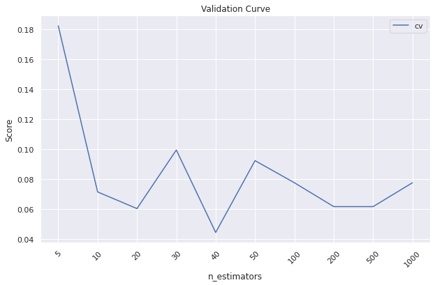

```python
plt.figure(figsize=(10,6))
plt.plot(scores_params, label = 'cv')
plt.xticks(np.arange(len(n_estimators)), n_estimators, rotation=45)
plt.xlabel('n_estimators')
plt.ylabel('Score')
plt.title('Validation Curve')
plt.legend()
plt.show()
```

```python
rf = RandomForestClassifier(n_estimators=50)
rf.fit(X_train,y_train)
pred = rf.predict(X_test)
metrics.accuracy_score(y_true = y_test, y_pred = pred)
```

```
0.9291237113402062
```

```python
print (metrics.classification_report(y_test, pred))
```

```
              precision    recall  f1-score   support

           0       0.94      0.99      0.96       725
           1       0.25      0.04      0.07        51

    accuracy                           0.93       776
   macro avg       0.59      0.52      0.52       776
weighted avg       0.89      0.93      0.90       776
```

However when testing this using the test data, this doesn't end up being true. Random Forest seems to be unable to learn the instances were class = 1 very well.

Let me try gridsearch anyways to see if perhaps a combination of parameters works better.

```python
params = dict(
    min_samples_split = [2,5,10, 20, 50,100, 200,  500, 1000],
    max_depth = [None,1,2,5,10],
    n_estimators = [5,10,20,50,100,200]
)
rf = RandomForestClassifier()
gs = GridSearchCV(estimator=rf, param_grid=params, scoring='f1', cv=cv, n_jobs=-1)
gs.fit(X_train, y_train)
gs.best_params_
```

```
{'max_depth': None, 'min_samples_split': 5, 'n_estimators': 10}
```

```python
best_estimator = gs.best_estimator_

pred = best_estimator.predict(X_test)
metrics.accuracy_score(y_test, pred)
```

```
0.9317010309278351
```

```python
confusion_matrix =  pd.crosstab(index = y_test, columns=pred.ravel(), rownames=['Expected'], colnames=['Predicted'])
confusion_matrix
```

| Predicted Expected | 0 | 1 |
| --- | --- | --- |
| 0 | 722 | 3 |
| 1 | 50 | 1 |

```python
print(metrics.classification_report(y_test, pred))
```

```
              precision    recall  f1-score   support

           0       0.94      1.00      0.96       725
           1       0.25      0.02      0.04        51

    accuracy                           0.93       776
   macro avg       0.59      0.51      0.50       776
weighted avg       0.89      0.93      0.90       776
```

# **AdaBoosting**

```python
ab = AdaBoostClassifier()
ab.fit(X_train,y_train)

pred = ab.predict(X_train)
metrics.accuracy_score(y_true = y_train, y_pred = pred)
```

```
0.9369469026548672
```

```python
pred = ab.predict(X_test)
metrics.accuracy_score(y_true = y_test, y_pred = pred)
```

```
0.9213917525773195
```

```python
confusion_matrix =  pd.crosstab(index = y_test, columns=pred.ravel(), rownames=['Expected'], colnames=['Predicted'])
confusion_matrix
```

| Predicted Expected | 0 | 1 |
| --- | --- | --- |
| 0 | 712 | 13 |
| 1 | 48 | 3 |

```python
print (metrics.classification_report(y_test, pred))
```

```
              precision    recall  f1-score   support

           0       0.94      0.98      0.96       725
           1       0.19      0.06      0.09        51

    accuracy                           0.92       776
   macro avg       0.56      0.52      0.52       776
weighted avg       0.89      0.92      0.90       776
```

Not a good start. The model is struggling to predict 1's as the previous ones did. The f1 is very low at .09, the recall is low at .06 and the balanced accuracy is low at .52

Let me see if tuning the model will help

```python
params = dict(
    learning_rate = [.001, .01, .1, 1, 2, 4, 5, 10],
    n_estimators = [5,10,20,50,100,500,1000]
)
ab = AdaBoostClassifier()
gs = GridSearchCV(estimator=ab, param_grid=params, scoring='f1', cv=cv, n_jobs=-1)
gs.fit(X_train, y_train)
gs.best_params_
```

```
{'learning_rate': 1, 'n_estimators': 500}
```

```python
best_estimator = gs.best_estimator_

pred = best_estimator.predict(X_test)
metrics.accuracy_score(y_test, pred)
```

```
0.9188144329896907
```

```python
confusion_matrix =  pd.crosstab(index = y_test, columns=pred.ravel(), rownames=['Expected'], colnames=['Predicted'])
confusion_matrix
```

| Predicted Expected | 0 | 1 |
| --- | --- | --- |
| 0 | 710 | 15 |
| 1 | 48 | 3 |

```python
print (metrics.classification_report(y_test, pred))
```

```
              precision    recall  f1-score   support

           0       0.94      0.98      0.96       725
           1       0.17      0.06      0.09        51

    accuracy                           0.92       776
   macro avg       0.55      0.52      0.52       776
weighted avg       0.89      0.92      0.90       776
```

This did nothing to improve the model. Adaboosting is not working for this data.

# **Gradient Boosting**

I have high hopes for gradient boosting as it's worked very well in the past assignments.

```python
gb = GradientBoostingClassifier()
gb.fit(X_train,y_train)

pred = gb.predict(X_train)
metrics.accuracy_score(y_true = y_train, y_pred = pred)
```

```
0.9679203539823009
```

```python
pred = gb.predict(X_test)
metrics.accuracy_score(y_true = y_test, y_pred = pred)
```

```
0.9368556701030928
```

```python
confusion_matrix =  pd.crosstab(index = y_test, columns=pred.ravel(), rownames=['Expected'], colnames=['Predicted'])
confusion_matrix
```

| Predicted Expected | 0 | 1 |
| --- | --- | --- |
| 0 | 720 | 5 |
| 1 | 44 | 7 |

```python
print (metrics.classification_report(y_test, pred))
```

```
              precision    recall  f1-score   support

           0       0.94      0.99      0.97       725
           1       0.58      0.14      0.22        51

    accuracy                           0.94       776
   macro avg       0.76      0.57      0.59       776
weighted avg       0.92      0.94      0.92       776
```

This is the highest f1 score so far excluding the gaussianNB model. However, the recall is still quite low. The reason behind the high f1 is because the precision is pretty high. This means that it's not predicting 1's as much as it should but the ones it does predict are typically correct.

The balanced accuracy is .555

Let's try tuning this model:

```python
learning_rate = [.0001, .001, .01, .1, 1, 2, 4, 5, 10]

scores_params = []
for m in learning_rate:
    gb = GradientBoostingClassifier(learning_rate=m)
    scores = cross_val_score(gb, X=X_train, y=y_train, scoring='f1', cv=cv)
    scores_params.append(scores.mean())
```

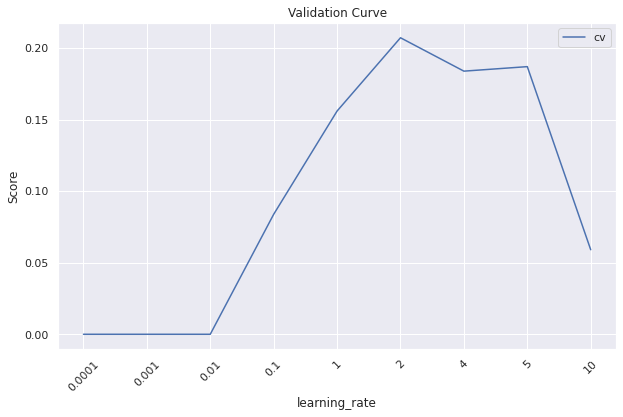

```python
plt.figure(figsize=(10,6))
plt.plot(scores_params, label = 'cv')
plt.xticks(np.arange(len(learning_rate)), learning_rate, rotation=45)
plt.xlabel('learning_rate')
plt.ylabel('Score')
plt.title('Validation Curve')
plt.legend()
plt.show()
```

Looks like a learning rate of 2 gives the best result.

```python
gb = GradientBoostingClassifier(learning_rate=2)
gb.fit(X_train,y_train)
pred = gb.predict(X_test)
metrics.accuracy_score(y_true = y_test, y_pred = pred)
```

```
0.7989690721649485
```

```python
print (metrics.classification_report(y_test, pred))
```

```
              precision    recall  f1-score   support

           0       0.97      0.81      0.88       725
           1       0.18      0.59      0.28        51

    accuracy                           0.80       776
   macro avg       0.57      0.70      0.58       776
weighted avg       0.91      0.80      0.84       776
```

These results surpised me quite as bit as this ended up being a pretty great model. It might even best the GaussianNB model.

The f1 is at .28 and the recall jumped all the way to .59.

The balanced accuracy is .7, which is the best so far.

Let's see the confusion matrix:

```python
confusion_matrix =  pd.crosstab(index = y_test, columns=pred.ravel(), rownames=['Expected'], colnames=['Predicted'])
confusion_matrix
```

| Predicted Expected | 0 | 1 |
| --- | --- | --- |
| 0 | 590 | 135 |
| 1 | 21 | 30 |

We can see that it's predicting 1's a lot more which is both good and bad. In our scenario here it would be better to falsely predict a 1, than to falsely predict a 0. If you predict a hazardous event, but nothing happens, it's okay. But if you predict a non-hazardous seismic event, and it turns out to be hazardous, then both miners and equipment can be put in a less than ideal situation that can cause quite a bit of danger.

So even though, we are falsely predicting 1 a bit too often in this model, it's still arguably a better model than any of the previous ones.

Let's continue tuning:

```python
n_estimators = [5,10,20,30,40,50,100,200,500,1000]

scores_params = []
for m in n_estimators:
    gb = GradientBoostingClassifier(n_estimators=m)
    scores = cross_val_score(gb, X=X_train, y=y_train, scoring='f1', cv=cv)
    scores_params.append(scores.mean())
```

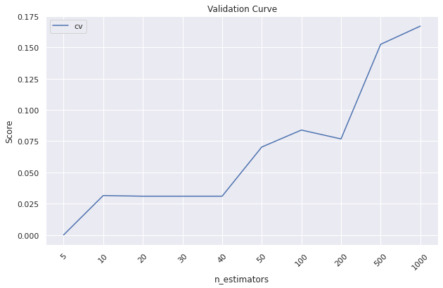

```python
plt.figure(figsize=(10,6))
plt.plot(scores_params, label = 'cv')
plt.xticks(np.arange(len(n_estimators)), n_estimators, rotation=45)
plt.xlabel('n_estimators')
plt.ylabel('Score')
plt.title('Validation Curve')
plt.legend()
plt.show()
```

The more estimators the better the f1 score.

```python
gb = GradientBoostingClassifier(n_estimators=1000)
gb.fit(X_train,y_train)
pred = gb.predict(X_test)
metrics.accuracy_score(y_true = y_test, y_pred = pred)
```

```
0.9252577319587629
```

```python
print (metrics.classification_report(y_test, pred))
```

```
              precision    recall  f1-score   support

           0       0.94      0.99      0.96       725
           1       0.23      0.06      0.09        51

    accuracy                           0.93       776
   macro avg       0.58      0.52      0.53       776
weighted avg       0.89      0.93      0.90       776
```

This however doesnt improve the model. Let's bring back the learning rate parameter from before.

```python
gb = GradientBoostingClassifier(n_estimators=10000, learning_rate=2)
gb.fit(X_train,y_train)
pred = gb.predict(X_test)
metrics.accuracy_score(y_true = y_test, y_pred = pred)
```

```
0.7976804123711341
```

```python
print (metrics.classification_report(y_test, pred))
```

```
              precision    recall  f1-score   support

           0       0.97      0.81      0.88       725
           1       0.18      0.59      0.28        51

    accuracy                           0.80       776
   macro avg       0.57      0.70      0.58       776
weighted avg       0.91      0.80      0.84       776
```

This returned the same results as before so it doesn't look like n_estimators plays much of a role here.

Let me try grid search and adjust a few other parameters:

```python
params = dict(
    learning_rate = [2],
    max_depth = [None,1,2,3,5,10],
    min_samples_split = [2,5,10,20,50,100]
)
gb = GradientBoostingClassifier()
gs = GridSearchCV(estimator=gb, param_grid=params, scoring='f1', cv=cv, n_jobs=-1)
gs.fit(X_train, y_train)
gs.best_params_
```

```
{'learning_rate': 2, 'max_depth': 3, 'min_samples_split': 100}
```

```python
best_estimator = gs.best_estimator_

pred = best_estimator.predict(X_test)
metrics.accuracy_score(y_test, pred)
```

```
0.884020618556701
```

```python
confusion_matrix =  pd.crosstab(index = y_test, columns=pred.ravel(), rownames=['Expected'], colnames=['Predicted'])
confusion_matrix
```

| Predicted Expected | 0 | 1 |
| --- | --- | --- |
| 0 | 680 | 45 |
| 1 | 45 | 6 |

```python
print (metrics.classification_report(y_test, pred))
```

```
              precision    recall  f1-score   support

           0       0.94      0.94      0.94       725
           1       0.12      0.12      0.12        51

    accuracy                           0.88       776
   macro avg       0.53      0.53      0.53       776
weighted avg       0.88      0.88      0.88       776
```

This did not improve the model unfortunetly.

So the best model using gradient boosting is only adjusting learning rate.

```python
gb = GradientBoostingClassifier(learning_rate=2)
gb.fit(X_train,y_train)
pred = gb.predict(X_test)
metrics.accuracy_score(y_true = y_test, y_pred = pred)
```

```
0.7989690721649485
```

```python
print (metrics.classification_report(y_test, pred))
```

```
              precision    recall  f1-score   support

           0       0.97      0.81      0.88       725
           1       0.18      0.59      0.28        51

    accuracy                           0.80       776
   macro avg       0.57      0.70      0.58       776
weighted avg       0.91      0.80      0.84       776
```

# **SVC**

```python
estimator = SVC(kernel ='rbf')
```

```python
estimator.fit(X_train, y_train)
pred = estimator.predict(X_test)
```

```python
confusion_matrix =  pd.crosstab(index = y_test, columns=pred.ravel(), rownames=['Expected'], colnames=['Predicted'])
confusion_matrix
```

| Predicted Expected | 0 |
| --- | --- |
| 0 | 725 |
| 1 | 51 |

```python
print (metrics.classification_report(y_test, pred))
```

```
              precision    recall  f1-score   support

           0       0.93      1.00      0.97       725
           1       0.00      0.00      0.00        51

    accuracy                           0.93       776
   macro avg       0.47      0.50      0.48       776
weighted avg       0.87      0.93      0.90       776
```

Using SVC isn't netting any results but perhaps some tuning will change this. SVC worked well in a previous assignment so I have hope it'll work well here.

```python
estimator2 = SVC(kernel ='rbf')
```

```python
params = dict(
    C = [0.00001, 0.0001, 0.001, 0.01, 0.1,1,2,5,10,60,100,500,1000],
    gamma = [0.0001,0.001,0.01,0.1, 1]
)
```

```python
gs = GridSearchCV(estimator=estimator2, param_grid=params, scoring='f1', n_jobs=-1)
gs.fit(X_train, y_train)
gs.best_params_
```

```
{'C': 1e-05, 'gamma': 0.0001}
```

```python
best_estimator = gs.best_estimator_
pred = best_estimator.predict(X_test)
confusion_matrix =  pd.crosstab(index = y_test, columns=pred.ravel(), rownames=['Expected'], colnames=['Predicted'])
confusion_matrix
```

| Predicted Expected | 0 |
| --- | --- |
| 0 | 725 |
| 1 | 51 |

Using these results in the model only predicting 0's for everything which we don't want. Perhaps I can try gridsearch using recall as the scoring.

```python
estimator3 = SVC(kernel ='rbf')
```

```python
params = dict(
    C = [0.00001, 0.0001, 0.001, 0.01, 0.1,1,2,5,10,60,100,500,1000],
    gamma = [0.0001,0.001,0.01,0.1, 1]
)
```

```python
gs = GridSearchCV(estimator=estimator3, param_grid=params, scoring='recall', cv=cv, n_jobs=-1)
gs.fit(X_train, y_train)
gs.best_params_
```

```
{'C': 1e-05, 'gamma': 0.0001}
```

```python
best_estimator = gs.best_estimator_
pred = best_estimator.predict(X_test)
confusion_matrix =  pd.crosstab(index = y_test, columns=pred.ravel(), rownames=['Expected'], colnames=['Predicted'])
confusion_matrix
```

| Predicted Expected | 0 |
| --- | --- |
| 0 | 725 |
| 1 | 51 |

Again I get the same result. It doesn't seem like SVC is a good fit for this problem. I tried using some of the other kernels and none of them were working well or giving better results than rbf.

```python
estimator4 = SVC(kernel ='poly')
```

```python
estimator4.fit(X_train, y_train)
pred = estimator4.predict(X_test)
```

```python
confusion_matrix =  pd.crosstab(index = y_test, columns=pred.ravel(), rownames=['Expected'], colnames=['Predicted'])
confusion_matrix
```

| Predicted Expected | 0 |
| --- | --- |
| 0 | 725 |
| 1 | 51 |

# **Other Models**

I'd like to try some other models that weren't covered in class as well or at least not used in the assignments

**SGD**

```python
clf = SGDClassifier()
clf.fit(X_train,y_train)
```

```
SGDClassifier()
```

```python
pred = clf.predict(X_test)
confusion_matrix =  pd.crosstab(index = y_test, columns=pred.ravel(), rownames=['Expected'], colnames=['Predicted'])
confusion_matrix
```

| Predicted Expected | 0 | 1 |
| --- | --- | --- |
| 0 | 17 | 708 |
| 1 | 3 | 48 |

The base SGD classifier did not net very good results. Let's try changing some parameters

```python
params = dict(
    alpha = [0.0001,.001,.01,.1,1],
    penalty = ['l2','l1','elasticnet'],
    max_iter = [100,1000]
)
clf = SGDClassifier()
gs = GridSearchCV(estimator=clf, param_grid=params, scoring='f1', cv=cv, n_jobs=-1)
gs.fit(X_train, y_train)
gs.best_params_
```

```
{'alpha': 0.001, 'max_iter': 1000, 'penalty': 'elasticnet'}
```

```python
best_estimator = gs.best_estimator_

pred = best_estimator.predict(X_test)
metrics.accuracy_score(y_test, pred)
```

```
0.9342783505154639
```

```python
confusion_matrix =  pd.crosstab(index = y_test, columns=pred.ravel(), rownames=['Expected'], colnames=['Predicted'])
confusion_matrix
```

| Predicted Expected | 0 |
| --- | --- |
| 0 | 725 |
| 1 | 51 |

```python
print (metrics.classification_report(y_test, pred))
```

```
              precision    recall  f1-score   support

           0       0.93      1.00      0.97       725
           1       0.00      0.00      0.00        51

    accuracy                           0.93       776
   macro avg       0.47      0.50      0.48       776
weighted avg       0.87      0.93      0.90       776
```

**Perceptron**

I tried several different hyperparameters, unfortunetly the model always netted the same result - predicting 0 for everything.

```python
clf = Perceptron(penalty='l2')
clf.fit(X_train,y_train)
pred = clf.predict(X_test)
confusion_matrix =  pd.crosstab(index = y_test, columns=pred.ravel(), rownames=['Expected'], colnames=['Predicted'])
confusion_matrix
```

| Predicted Expected | 0 |
| --- | --- |
| 0 | 725 |
| 1 | 51 |

```python
print (metrics.classification_report(y_test, pred))
```

```
              precision    recall  f1-score   support

           0       0.93      1.00      0.97       725
           1       0.00      0.00      0.00        51

    accuracy                           0.93       776
   macro avg       0.47      0.50      0.48       776
weighted avg       0.87      0.93      0.90       776
```

Let me try a multi layer perceptron instead!

**MLP**

```python
clf = MLPClassifier()
clf.fit(X_train,y_train)
pred = clf.predict(X_test)
confusion_matrix =  pd.crosstab(index = y_test, columns=pred.ravel(), rownames=['Expected'], colnames=['Predicted'])
confusion_matrix
```

| Predicted Expected | 0 | 1 |
| --- | --- | --- |
| 0 | 722 | 3 |
| 1 | 51 | 0 |

```python
print (metrics.classification_report(y_test, pred))
```

```
              precision    recall  f1-score   support

           0       0.93      1.00      0.96       725
           1       0.00      0.00      0.00        51

    accuracy                           0.93       776
   macro avg       0.47      0.50      0.48       776
weighted avg       0.87      0.93      0.90       776
```

It's important to note that rerunning the code tends to get drastically different results each time.

Let's try tweaking this a little.

```python
clf = MLPClassifier(solver='adam', activation = 'identity', batch_size=10, hidden_layer_sizes=(100,3), alpha=.01, learning_rate_init = .01)
clf.fit(X_train,y_train)
pred = clf.predict(X_test)
confusion_matrix =  pd.crosstab(index = y_test, columns=pred.ravel(), rownames=['Expected'], colnames=['Predicted'])
confusion_matrix
```

| Predicted Expected | 0 |
| --- | --- |
| 0 | 725 |
| 1 | 51 |

```python
print (metrics.classification_report(y_test, pred))
```

```
              precision    recall  f1-score   support

           0       0.93      1.00      0.97       725
           1       0.00      0.00      0.00        51

    accuracy                           0.93       776
   macro avg       0.47      0.50      0.48       776
weighted avg       0.87      0.93      0.90       776
```

**Nearest Centroid**

Although KNN didn't work too well, I wanted to try nearest centroid. I think it's likely too simple of a model to work well for this data. But let's see.

```python
clf = NearestCentroid()
clf.fit(X_train,y_train)
pred = clf.predict(X_test)
confusion_matrix =  pd.crosstab(index = y_test, columns=pred.ravel(), rownames=['Expected'], colnames=['Predicted'])
confusion_matrix
```

| Predicted Expected | 0 | 1 |
| --- | --- | --- |
| 0 | 652 | 73 |
| 1 | 40 | 11 |

```python
print (metrics.classification_report(y_test, pred))
```

```
              precision    recall  f1-score   support

           0       0.94      0.90      0.92       725
           1       0.13      0.22      0.16        51

    accuracy                           0.85       776
   macro avg       0.54      0.56      0.54       776
weighted avg       0.89      0.85      0.87       776
```

This is actually working better than some of the other models tried. It's not as good as the best models but it isn't all that bad.

Let me try adjusting some parameters:

```python
clf = NearestCentroid(metric ='manhattan')
clf.fit(X_train,y_train)
pred = clf.predict(X_test)
confusion_matrix =  pd.crosstab(index = y_test, columns=pred.ravel(), rownames=['Expected'], colnames=['Predicted'])
confusion_matrix
```

| Predicted Expected | 0 | 1 |
| --- | --- | --- |
| 0 | 523 | 202 |
| 1 | 19 | 32 |

```python
print (metrics.classification_report(y_test, pred))
```

```
              precision    recall  f1-score   support

           0       0.96      0.72      0.83       725
           1       0.14      0.63      0.22        51

    accuracy                           0.72       776
   macro avg       0.55      0.67      0.53       776
weighted avg       0.91      0.72      0.79       776
```

This is a fairly successful model as it's predicting 1's pretty well as seen by the relatively high recall. The f1 score is .22, the biggest issue is the fairly low precision.

```python
clf = NearestCentroid(metric ='manhattan', shrink_threshold=1)
clf.fit(X_train,y_train)
pred = clf.predict(X_test)
confusion_matrix =  pd.crosstab(index = y_test, columns=pred.ravel(), rownames=['Expected'], colnames=['Predicted'])
confusion_matrix
```

| Predicted Expected | 0 | 1 |
| --- | --- | --- |
| 0 | 575 | 150 |
| 1 | 21 | 30 |

```python
print (metrics.classification_report(y_test, pred))
```

```
              precision    recall  f1-score   support

           0       0.96      0.79      0.87       725
           1       0.17      0.59      0.26        51

    accuracy                           0.78       776
   macro avg       0.57      0.69      0.57       776
weighted avg       0.91      0.78      0.83       776
```

This is the best model I was able to come up with using Nearest Centroid. It ranks among the best for this dataset along with gradient boosting and gaussian naive bayes. We can see a high recall of .59 and a balanced accuracy of .69 (the same as gaussian NB). The F1 is slightly lower than GNB however at .26 as is the precision.

**Bernoulli NB**

I wanted to try some of the other Naive Bayes models in the Sklearn library. The one that seemed to fit the data the best was the bernoulli naive bayes model:

```python
clf = BernoulliNB()
clf.fit(X_train,y_train)
pred = clf.predict(X_test)
confusion_matrix =  pd.crosstab(index = y_test, columns=pred.ravel(), rownames=['Expected'], colnames=['Predicted'])
confusion_matrix
```

| Predicted Expected | 0 | 1 |
| --- | --- | --- |
| 0 | 600 | 125 |
| 1 | 18 | 33 |

```python
print (metrics.classification_report(y_test, pred))
```

```
              precision    recall  f1-score   support

           0       0.97      0.83      0.89       725
           1       0.21      0.65      0.32        51

    accuracy                           0.82       776
   macro avg       0.59      0.74      0.60       776
weighted avg       0.92      0.82      0.86       776
```

Even with default parameters, this is already among the best models. We can see a recall of .65 and a balanced average of .74 (the highest by far). This model also has a f1 score on par with the Gaussian NB. The percision is a tad bit lower. This may be the best model so far, lets tune it a bit.

```python
clf = BernoulliNB(alpha=1, binarize=.1)
clf.fit(X_train,y_train)
pred = clf.predict(X_test)
confusion_matrix =  pd.crosstab(index = y_test, columns=pred.ravel(), rownames=['Expected'], colnames=['Predicted'])
confusion_matrix
```

| Predicted Expected | 0 | 1 |
| --- | --- | --- |
| 0 | 600 | 125 |
| 1 | 18 | 33 |

```python
print (metrics.classification_report(y_test, pred))
```

```
              precision    recall  f1-score   support

           0       0.97      0.83      0.89       725
           1       0.21      0.65      0.32        51

    accuracy                           0.82       776
   macro avg       0.59      0.74      0.60       776
weighted avg       0.92      0.82      0.86       776
```

Changing the different parameters unfortunetly did not improve performance, but either way this is the best model so far.

# **Best Models & Reflection**

I selected three models that had similar performances as the best models. I ranked them in order from best to worst.

**1) Bernoulli NB**

```python
clf = BernoulliNB()
clf.fit(X_train,y_train)
pred_final = clf.predict(X_test)
confusion_matrix =  pd.crosstab(index = y_test, columns=pred_final.ravel(), rownames=['Expected'], colnames=['Predicted'])
confusion_matrix
```

| Predicted Expected | 0 | 1 |
| --- | --- | --- |
| 0 | 600 | 125 |
| 1 | 18 | 33 |

```python
print (metrics.classification_report(y_test, pred_final))
```

```
              precision    recall  f1-score   support

           0       0.97      0.83      0.89       725
           1       0.21      0.65      0.32        51

    accuracy                           0.82       776
   macro avg       0.59      0.74      0.60       776
weighted avg       0.92      0.82      0.86       776
```

The Bernoulli Naive Bayes model is the best model. It has by far the highest balanced accuracy of .74. This means that it is capable of predicting both 1's (hazardous seismic event in the next shift) and 0's (non hazardous seimsic event) relatively well.

The objective here is to be able to predict those hazards. It is far more important for a model to predict hazards than to predict non-hazards. Predicting that something is hazardous will at least allow the miners to take the proper precautions. If you predict something as non-hazardous but it ends up being hazardous, then you might have devastating consequences because the proper precautions won't be taken. That's why I'm not as concerned about a very predicting accuracy for 0's. Of course, the best model should be able to predict both relatively well, but the key is to be able to predict the hazards.

This model is able to do that. Yes the percision is a little low because there is many false positives. But it's not that much lower than the second best model. And again, in a real world scenario, a false positive is not ideal but it's okay and a better outcome than predicting a false negative.

Out of all the models, this one has the highest recall at .65, it has the highest balanced accuracy at .74, it is tied for the highest f1 score with .32. It is definetly the best and most useful model of the ones attempted.

**2) Gradient Boosting**

```python
gb = GradientBoostingClassifier(learning_rate=2)
gb.fit(X_train,y_train)
pred = gb.predict(X_test)
confusion_matrix =  pd.crosstab(index = y_test, columns=pred.ravel(), rownames=['Expected'], colnames=['Predicted'])
confusion_matrix
```

| Predicted Expected | 0 | 1 |
| --- | --- | --- |
| 0 | 590 | 135 |
| 1 | 21 | 30 |

```python
print (metrics.classification_report(y_test, pred))
```

```
              precision    recall  f1-score   support

           0       0.97      0.81      0.88       725
           1       0.18      0.59      0.28        51

    accuracy                           0.80       776
   macro avg       0.57      0.70      0.58       776
weighted avg       0.91      0.80      0.84       776
```

This model is very similar to the Bernoulli Naive Bayes model which is why I chose it for second place, although it's very interchangable with model 3. The Gradient Boosting model was again pretty good at predicting both 1's and 0's. The balanced accuracy of the model is 0.7 which is really good although not as good as the BernoulliNB model. Because, this model is capable of predicting hazardous events a bit metter than the GaussianNB model, I selected it in second place. However, this model does have a slightly lower f1 score and precision.

**3) Gaussian NB**

```python
gnb = GaussianNB(var_smoothing = 0.000000000001)
gnb.fit(X_train, y_train)
pred = gnb.predict(X_test)
confusion_matrix =  pd.crosstab(index = y_test, columns=pred.ravel(), rownames=['Expected'], colnames=['Predicted'])
confusion_matrix
```

| Predicted Expected | 0 | 1 |
| --- | --- | --- |
| 0 | 646 | 79 |
| 1 | 26 | 25 |

```python
print (metrics.classification_report(y_test, pred))
```

```
              precision    recall  f1-score   support

           0       0.96      0.89      0.92       725
           1       0.24      0.49      0.32        51

    accuracy                           0.86       776
   macro avg       0.60      0.69      0.62       776
weighted avg       0.91      0.86      0.89       776
```

Finally I placed the Gaussian Naive Bayes model in 3rd place. It is still a good model for this data. The balanced accuracy is .69, so it really is close to the other two models. However, it isn't as capable of predicting hazardous events (1). It's overall accuracy may be higher at .86 but that's a little misleading as it's all thanks to its ability to predict 0's. The f1 score is on par with the BernoulliNB model as is the precision. Again the biggest issue here is that the recall and balanced accuracy is lower than the other models.

**Final Findings and Future Improvements**

To reiterate, the best model for this data is the Bernoulli Naive Bayes model. But both Gradient Boosting and GaussianNB models do come close. The biggest issue with this problem is the dataset. When it comes to predicting sort of natural hazards or disasters like seimsmic activity, there is a lot more data of cases were it isn't hazardous than hazardous. So, in this dataset I only had 2500 data points to begin with and of that only 6% or so were actually hazardous. This means that there isn't a lot of data for the models to be trained out, and also when evaluating we get misleading accuracies because it's predicting the majority class very well and not the small minority class.

Given more time, I'd like to try out several other models. Perhaps look at other python libraries becauses sklearn to find other models. I'd also think about somehow getting more data. Maybe, there are other datasets or there are websites that post seismic readings. Perhaps it'd also be possible to use existing data points to create new data by slightly modifying them. I think having more data would also better verify that the models are good.

But overall, I'm fairly happy with how this project turned out!

**FinalPredictions (using Bernoulli NB model):**

```python
pred_final
```

```
array([1, 0, 0, 0, 1, 0, 1, 0, 0, 1, 1, 0, 0, 0, 0, 0, 0, 0, 0, 0, 1, 1,
       0, 0, 0, 0, 1, 0, 1, 0, 1, 0, 0, 1, 0, 0, 0, 0, 0, 0, 1, 0, 0, 1,
       0, 1, 0, 0, 0, 0, 0, 1, 0, 1, 0, 0, 0, 0, 0, 0, 1, 0, 0, 0, 0, 0,
       0, 0, 0, 0, 0, 0, 0, 0, 0, 0, 0, 0, 0, 0, 0, 0, 0, 0, 0, 0, 0, 0,
       0, 0, 1, 0, 1, 0, 0, 0, 0, 0, 0, 0, 0, 0, 0, 0, 0, 0, 1, 0, 0, 1,
       0, 0, 1, 1, 0, 0, 0, 0, 0, 0, 0, 0, 0, 0, 0, 0, 0, 0, 0, 1, 0, 0,
       0, 1, 0, 1, 0, 0, 0, 0, 0, 0, 0, 1, 0, 1, 1, 0, 1, 0, 1, 0, 0, 0,
       1, 0, 0, 0, 0, 0, 0, 1, 0, 0, 0, 0, 0, 0, 0, 0, 0, 0, 0, 0, 0, 0,
       0, 0, 0, 0, 1, 0, 0, 0, 0, 0, 0, 0, 1, 0, 0, 1, 0, 0, 0, 0, 1, 0,
       0, 0, 1, 0, 0, 0, 0, 1, 0, 0, 0, 1, 0, 0, 1, 0, 0, 0, 0, 0, 0, 0,
       0, 0, 1, 0, 0, 1, 0, 1, 0, 0, 0, 0, 1, 0, 1, 0, 0, 0, 0, 1, 0, 0,
       0, 0, 0, 0, 0, 0, 0, 0, 0, 1, 0, 1, 0, 0, 0, 0, 0, 0, 0, 0, 1, 0,
       0, 1, 0, 0, 0, 1, 0, 0, 1, 0, 0, 0, 0, 0, 0, 0, 1, 0, 0, 0, 0, 1,
       0, 0, 0, 1, 0, 0, 0, 1, 0, 0, 0, 0, 0, 0, 0, 0, 0, 0, 0, 0, 0, 0,
       0, 0, 0, 0, 0, 0, 1, 0, 0, 0, 0, 0, 1, 0, 0, 1, 0, 1, 0, 0, 0, 1,
```

[output cut: 21 more lines]

```python
confusion_matrix =  pd.crosstab(index = y_test, columns=pred_final.ravel(), rownames=['Expected'], colnames=['Predicted'])
confusion_matrix
```

| Predicted Expected | 0 | 1 |
| --- | --- | --- |
| 0 | 600 | 125 |
| 1 | 18 | 33 |

```python
print (metrics.classification_report(y_test, pred_final))
```

```
              precision    recall  f1-score   support

           0       0.97      0.83      0.89       725
           1       0.21      0.65      0.32        51

    accuracy                           0.82       776
   macro avg       0.59      0.74      0.60       776
weighted avg       0.92      0.82      0.86       776
```